# Palmer Penguins

STAT 6730: Data Analysis Project

Frank Leyva Castro, Yousef Qaddura, Changrui Wang

### Introduction

The `palmerpenguins` raw data were collected over 2007-2009 and made available by Dr. Kristen Gorman and the Palmer Station, Antarctica LTER, a member of the Long Term Ecological Research Network. The cleaned-up dataset `penguins` contains complete data for size measurements of 333 adult foraging penguins of 3 different species (Adelie, Gentoo, Chinstrap), collected from 3 different Islands (Torgersen, Biscoe, Dream).

Our questions of interest are three-fold:

1. How does body mass depend on the other features? More specifically, what are the best choices of linear regression models that explain body mass? Here best is in the sense of BIC, AIC and similar measures. This question is answered through best subsets regression.
2. Are the chosen models distinguished in terms of predictive power? We use $15$-fold cross-validation to uncover the answer. We will find that all three have similar predictive power and hence choose to proceed with the simplest model as the model of choice.
3. What are the statistical properties of the coefficients for the model of choice? This question is answered using bootstrap.

### Expolatory Data Analysis

Before embarking on our questions, we remark on our observations from Figure 1. Firth, we observe that changing sex from female to male remarkably causes an increase in the body mass axis ticks. Next, body mass is positively correlated with all size measurements. The Gentoo species (blue) is distinguished in having much higher body mass than other species. The other two species differ on their bill length. We also include an extra Figure 2 which shows much more statistical amongst all pairs of variables although we feel that it is enough to have commented on Figure 1 for the purposes of our analysis.

### Best Subsets Regression Result

- Simple (Model A)

$$\scriptstyle \text{BodyMass } = \text{
Male } + \text{ Gentoo } + \text{ Bill Depth } + \text{ Flipper
Length}$$

- Complex without Interactions (Model B)

$$\scriptstyle
\begin{aligned}
\text{BodyMass } = \text{ Male } &+ \text{ Gentoo }+\text{ Chinstrap
}\\
&+\text{ Bill Length } +\text{ Bill Depth } + \text{ Flipper Length}
\end{aligned}$$

- Complex with Interactions (Model C)

$$\scriptstyle\begin{aligned}\text{BodyMass } =
\text{ Male } &+ \text{ Gentoo }+\text{ Chinstrap }\\
&+\text{ Bill Length } *\text{ Bill Depth }+\text{ Bill Length
}*\text{ Flipper Length }
\end{aligned}$$

### Anova Analysis

To analyze the models, begin by performing ANOVA $F$-tests. With Model $A$ as null and $B$ as alternative, the $p$-value of the $F$-test is given by 0.0087314. With Model $B$ as null and $C$ as alternative, the $p$-value of the $F$-test is given by 0.0188342. This shows that Model $C$ best explains the variation in body mass compared to the other two models. This would be the model of choice if such characteristic is desired.

### $15$-fold Cross-Validation

In this analysis, our model of choice will be based on its predictive power and simplicity. By performing $15$-fold cross-validation (see Table 3), we observe that the three models have very similar average mean squared errors and comparable standard errors or mean squares across the folds. From this, we conclude that our model of choice is Model A, the simplest one as it is simplest with similar predictive power to the other two models.

## Bootstrap Confidence Intervals

The bootstrap $\% 95$ confidence intervals for our model of choice coefficients are shown in Table 4. We observe that none of them contain the value zero and all have relatively acceptable widths. This entails that there is no strong evidence of bias toward model A in the data!

## Conclusions

Overall, the *penguins* data-set is an excellent practice for newcomers into data analysis. The models and plots show clear species and sex differences and the remarkable dependence of a penguin’s body mass on its bill and flipper characteristics. Model C highlighted the importance of interaction terms in explaining variance, but also gives a warning about the challenges of interpretation. All models considered have similar predictive power and the best model of choice recommended is the simplest!

### Figure Appendix

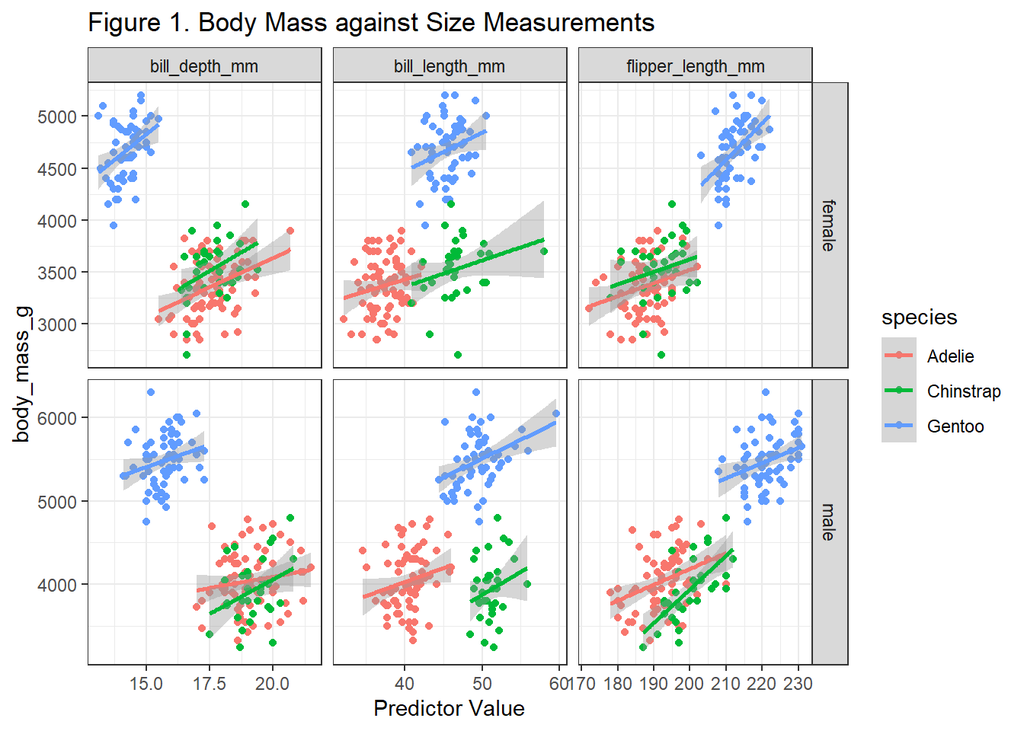

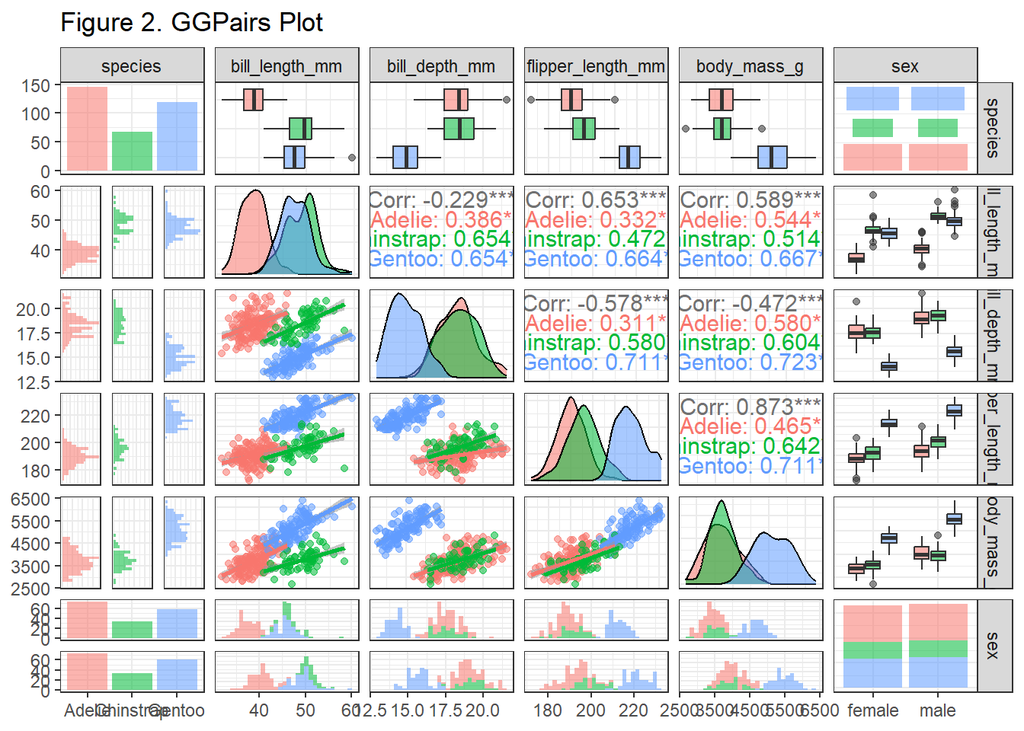

Table 1. Best Subsets Regression Result

|  | male | Chinstrap | Gentoo | BillL | BillD | FlipperL | BD*BL | FL*BL | FL*BD | FL*BDBL |
| --- | --- | --- | --- | --- | --- | --- | --- | --- | --- | --- |
| 1 ( 1 ) |  |  |  |  |  | * |  |  |  |  |
| 2 ( 1 ) | * |  | * |  |  |  |  |  |  |  |
| 3 ( 1 ) | * |  | * |  |  |  |  |  | * |  |
| 4 ( 1 ) | * |  | * |  | * | * |  |  |  |  |
| 5 ( 1 ) | * |  | * |  | * |  | * | * |  |  |
| 6 ( 1 ) | * | * | * |  | * |  | * | * |  |  |
| 7 ( 1 ) | * | * | * | * | * |  | * |  | * |  |
| 8 ( 1 ) | * | * | * | * | * |  | * |  | * | * |

Table 2. Best Subsets Regression Measure Results

| model.no | Mallow_C | BIC | R2 | AR2 | AIC |
| --- | --- | --- | --- | --- | --- |
| 1 | 300.928653 | -466.5291 | 0.7620922 | 0.7613734 | 1085.920 |
| 2 | 79.071488 | -606.9337 | 0.8466372 | 0.8457078 | 1052.355 |
| 3 | 22.858018 | -652.6522 | 0.8686230 | 0.8674250 | 1041.821 |
| 4 | 17.844381 | -653.6268 | 0.8712718 | 0.8697020 | 1042.171 |
| 5 | 8.425038 | -659.1663 | 0.8755846 | 0.8736823 | 1041.411 |
| 6 | 6.198781 | -657.6579 | 0.8771808 | 0.8749203 | 1042.365 |
| 7 | 5.969181 | -654.1407 | 0.8780229 | 0.8753957 | 1043.808 |
| 8 | 7.692176 | -648.6183 | 0.8781275 | 0.8751183 | 1045.738 |

Table 3. 15-fold cross-validation

| Model | Mean Squared Error | Standard Error |
| --- | --- | --- |
| A | 85628.54 | 6899.618 |
| B | 84958.55 | 7240.633 |
| C | 85259.28 | 6470.569 |

Table 4. Bootstrap Confidence Intervals for Model A Coefficients

|  | Estimated.Coefficients | Lower.Bound | Upper.Bound |
| --- | --- | --- | --- |
| maleTRUE | 444.84014 | 347.5303 | 546.2287 |
| gentooTRUE | 1229.23800 | 1042.6639 | 1415.1893 |
| bill_depth_mm | 76.12165 | 38.0325 | 119.1671 |
| flipper_length_mm | 15.78925 | 11.7826 | 20.7536 |